# hw1

**Exercise 1.1.1**

Consider a floating-point set $\mathbb{F}$ defined by (1.1.1) and (1.1.2) with $d=4$.

(a) How many elements of $\mathbb{F}$ are there in the real interval $[1/2,4]$, including the endpoints?

With $d=4$, we have $z\in[0\colon2^d-1=15]$ and thus $f\in2^{-d}z=\{z/16\mid\forall z\}$.

With $e=-1$, we have $(1+f)2^e=\{16/32,17/32,\dots31/32\}$, 16 elements in $[1/2,1)$.

With $e=0$, we have $(1+f)2^e=\{16/16,17/16,\dots31/16\}$, 16 elements in $[1,2)$.

With $e=1$, we have $(1+f)2^e=\{16/8,17/8,\dots31/8\}$, 16 elements in $[2,4)$.

Add $4=(1+0/16)2^2$ to get 49 elements total in the real interval $[1/2,4]$.

(b) What is the element of $\mathbb{F}$ closest to the real number 1/10? (Hint: Find the interval $[2^n,2^{n+1})$ that contains $1/10$, then enumerate all the candidates in $\mathbb{F}$.)

$e=-4$ generates FPs on $1/10\in[1/16,1/8)$.

With $e=-4$, we have $(1+f)2^e={16/256,17/256,\dots,31/256}$, of which $26/256=(1+10/16)2^{-4}$ is closest.

(c) What is the smallest positive integer not in $\mathbb{F}$? (Hint: For what value of the exponent does the spacing between floating-point numbers become larger than 1?)

$e=4$ generates $\{16,17,\dots31\}$, every integer on $[16,32)$.

$(1+0/16)2^5=32$, and $(1+1/16)2^5=34$, skipping $33$. $33$ is the smallest positive integer not in $\mathbb{F}$.

**Exercise 1.1.2**

Prove that (1.1.5) is equivalent to (1.1.6). This means showing first that (1.1.5) implies (1.1.6), and then separately that (1.1.6) implies (1.1.5).

(1.1.5) states $\frac{|\text{fl}(x)-x|}{|x|}\leq\frac{2^{n-d-1}}{2^n}=\frac{1}{2}\epsilon_M$, and (1.1.6) states $\text{fl}(x)=x(1+\epsilon)$ for some $|\epsilon|\leq\frac{1}{2}\epsilon_M$.

(1.1.5) $\to$ (1.1.6):

$$\begin{align*} &\frac{|\text{fl}(x)-x|}{|x|}=|\frac{\text{fl}(x)-x}{x}|\leq\frac{1}{2}\epsilon_M\\ \to&\,-\frac{1}{2}\epsilon_M\leq\frac{\text{fl}(x)-x}{x}\leq\frac{1}{2}\epsilon_M\\ \end{align*}$$

Now assume $x>0$.

$$\begin{align*} \to&\,\text{fl}(x)-x\leq x\frac{1}{2}\epsilon_M\\ \to&\,\text{fl}(x)\leq x(1+\frac{1}{2}\epsilon_M) \end{align*}$$

Now if we set $\text{fl}(x)=x(1+\epsilon)$ where $\epsilon\leq\frac{1}{2}\epsilon_M$, we get exactly (1.1.6) for positive $\epsilon$.

If we instead assume $x<0$,

$$\begin{align*} \to&\,-x\frac{1}{2}\epsilon_M\geq\text{fl}(x)-x\\ \to&\,x(1-\frac{1}{2}\epsilon_M)\geq\text{fl}(x)\\ \end{align*}$$

Now if we set $\text{fl}(x)=x(1+\epsilon)$ where $-\epsilon\leq\frac{1}{2}\epsilon_M$, we get exactly (1.1.6) for negative $\epsilon$.

We can combine these into the given $|\epsilon|\leq\frac{1}{2}\epsilon_M$.

(1.1.6) $\to$ (1.1.5):

$$\begin{align*} &\text{fl}(x)=x(1+\epsilon),|\epsilon|\leq\frac{1}{2}\epsilon_M\\ \to&\,-\frac{1}{2}\epsilon_M\leq\epsilon\leq\frac{1}{2}\epsilon_M\\ \end{align*}$$

Now assume positive $\epsilon$.

$$\to\,\text{fl}(x)\leq x(1+\frac{1}{2}\epsilon_M)$$

We can walk back the algebraic manipulation shown in (1.1.5) $\to$ (1.1.6) to reach $\frac{|\text{fl}(x)-x|}{|x|}\leq\frac{1}{2}\epsilon_M$.

If we instead assume negative $\epsilon$,

$$\to\,x(1-\frac{1}{2}\epsilon_M)\geq\text{fl}(x)$$

We can again walk back the algebraic manipulation to reach the same $\frac{|\text{fl}(x)-x|}{|x|}\leq\frac{1}{2}\epsilon_M$.

As (1.1.5) $\to$ (1.1.6) and (1.1.6) $\to$ (1.1.5), they are equivalent.

**Exercise (1.2.1)**

Use (1.2.6) to derive the relative condition numbers of the following functions appearing in Table 1.2.1.

(a) $f(x)=x^p$

$$\kappa_f(x)=|\frac{x(x^p)'}{x^p}|=|\frac{xpx^{p-1}}{x^p}|=|\frac{xp}{x}|=|p|$$

(b) $f(x)=\ln x$

$$\kappa_f(x)=|\frac{x(\ln x)'}{\ln x}|=|\frac{x*1/x}{\ln x}|=\frac{1}{|\ln x|}$$

(c) $f(x)=\cos x$

$$\kappa_f(x)=|\frac{x(\cos x)'}{\cos x}|=|\frac{-x\sin x}{\cos x}|=|x\tan x|$$

(d) $f(x)=e^x$

$$\kappa_f(x)=|\frac{x(e^x)'}{e^x}|=|x|$$

**Exercise (1.2.3)**

Calculate the relative condition number of each function, and identify all values of $x$ at which $\kappa_f(x)\to\infty$ (including limits as $x\to\pm\infty$).

(a) $f(x)=\tanh x$

$$\kappa_f(x)=|\frac{x(\tanh x)'}{\tanh x}|=|\frac{x\,\text{sech}^2 x}{\tanh x}|=|\frac{x}{\text{sinh}\,x\,\text{cosh}\,x}|$$

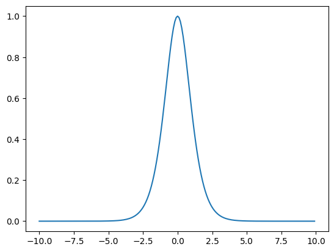

```python
import numpy as np
import matplotlib.pyplot as plt

x_axis = np.arange(-10, 10, 0.1)
plt.plot(x_axis, [abs(x / (np.sinh(x) * np.cosh(x))) for x in x_axis])
```

There are no values of $x$ that tend to infinity.

(b) $f(x)=\frac{e^x - 1}{x}$

$$\kappa_f(x)=|\frac{x(x^{-1}(e^x-1))'}{x^{-1}(e^x-1)}|=|\frac{e^x(x-1)+1}{e^x-1}|$$

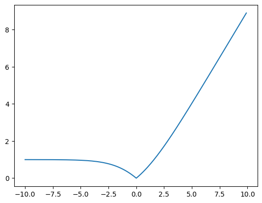

```python
import numpy as np
import matplotlib.pyplot as plt

x_axis = np.arange(-10, 10, 0.1)
plt.plot(x_axis, [abs((np.exp(x) * (x - 1) + 1) / (np.exp(x) - 1)) for x in x_axis])
```

As $x\to\infty$, $\kappa_f(x)\to\infty$.

(c) $f(x)=\frac{1-\cos x}{x}$

$$\kappa_f(x)=|\frac{x(x^{-1}(1-\cos x))'}{x^{-1}(1 - \cos x)}|=|\frac{x-1}{\tan\frac{x}{2}}|$$

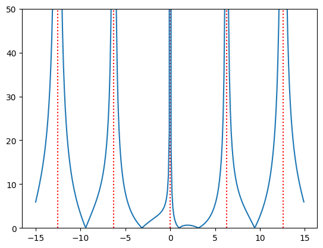

```python
import numpy as np
import matplotlib.pyplot as plt

x_axis = np.arange(-15, 15, 0.1)
plt.ylim(0, 50)
plt.vlines([c * 2 * np.pi for c in range(-2, 2 + 1)], 0, 50, "r", ":")
plt.plot(x_axis, [abs((x - 1) / np.tan(x / 2)) for x in x_axis])
```

$\kappa_f(x)\to\infty$ when $x=2k\pi$ for integer $k$.

**Exercise (1.2.8)**

Generalize (1.2.13) to finding a root of the $n$th degree polynomial $p(x)=a_nx^n+\cdots+a_1x+a_0$, and show that the relative condition number of a root $r$ with respect to perturbations only in $a_k$ is $\kappa_r(a_k)=|\frac{a_kr^{k-1}}{p'(r)}|$.

(1.2.13) states:

$$\kappa_f(a)=|\frac{a}{r_1}\cdot\frac{dr_1}{da}|=|\frac{ar_1}{2ar_1+b}|=|\frac{r_1}{r_1-r_2}|$$

For finding the conditioning of the leading coefficient of some quadratic $at^2+bt+c=0$ on some root $f(a)=r_1$.

For a general $n$th degree polynomial of the form $p(x)=a_nx^n+\cdots+a_1x+a_0$, we can follow the same steps outlined in the textbook.

Differentiating $a_nr_1^n+\cdots+a_kr_1^k+\cdots+a_1r_1+a_0$ implicitly with respect to $a_k$, holding all other $a_i$ fixed, yields

$$\begin{align*} &\frac{d}{da_k}(a_nr_1^n+\cdots+a_kr_1^k+\cdots+a_1r_1+a_0)\\ =\,& a_n(n)r_1^{n-1}\frac{dr_1}{da_k}+\cdots+(r_1^k + a_k(k)r_1^{k-1}\frac{dr_1}{da_k})+\cdots+a_1(1)r_1^0\frac{dr_1}{da_k}\\ =\,& \frac{dr_1}{da_k}(a_n(n)r_1^{n-1}+\cdots+a_k(k)r_1^{k-1}+\cdots+a_1)+r_1^k\stackrel{\text{SET}}{=}0\\ \to\,& \frac{dr_1}{da_k}=\frac{-r_1^k}{a_n(n)r_1^{n-1}+\cdots+a_1} \end{align*}$$

Now that we have a generalized equation for $\frac{dr_1}{da_k}$ and indeed any $\frac{dr}{da_k}$, we can find the condition number of a root $r$ with respect to perturbations only in $a_k$.

$$\kappa_r(a_k)=|\frac{a_k(dr/da_k)}{r}|=|\frac{a_k}{r}\cdot\frac{-r_1^k}{a_n(n)r_1^{n-1}+\cdots+a_1}|=|\frac{a_kr^{k-1}}{p'(r)}|$$

**Exercise (1.4.2)**

Let $f(x)=\frac{e^x-1}{x}$.

(a) Find the condition number $\kappa_f(x)$. What is the maximum of $\kappa_f(x)$ over $-1\leq x\leq1$?

As calculated in 1.2.3b,

$$\kappa_f(x)=|\frac{e^x(x-1)+1}{e^x-1}|$$

By way of Desmos, the maximum of $\kappa_f(x)$ over $-1\leq x\leq1$ is at the right bound $\kappa_f(1)=\frac{1}{e-1}$.

(b) Use the "obvious" algorithm `(exp(x) - 1) / x` to compute $f(x)$ at $x=10^{-2},10^{-3},10^{-4},\dots,10^{-11}$.

```python
import numpy as np

x_values = [10 ** e for e in range(-2, -11 - 1, -1)]

def obvious(x):
    return (np.exp(x) - 1) / x

obvious_algorithm = []
for x in x_values:
    y = obvious(x)
    obvious_algorithm.append(y)
    print(f"f({x:e}) = {y}")
```

```
f(1.000000e-02) = 1.005016708416795
f(1.000000e-03) = 1.0005001667083846
f(1.000000e-04) = 1.000050001667141
f(1.000000e-05) = 1.000005000006965
f(1.000000e-06) = 1.0000004999621837
f(1.000000e-07) = 1.0000000494336803
f(1.000000e-08) = 0.999999993922529
f(1.000000e-09) = 1.000000082740371
f(1.000000e-10) = 1.000000082740371
f(1.000000e-11) = 1.000000082740371
```

(c) Create a second algorithm from the first 8 terms of the Maclaurin series, i.e.,

$$f(x)\approx p(x)=1+\frac{1}{2!}x+\frac{1}{3!}x^2+\cdots+\frac{1}{8!}x^7.$$

Evaluate it at the same values of $x$ as in part (b).

```python
from math import factorial

def maclaurin(x):
    return sum([(1 / factorial(n)) * (x ** (n - 1)) for n in range(1, 8 + 1)])

maclaurin_algorithm = []
for x in x_values:
    y = maclaurin(x)
    maclaurin_algorithm.append(y)
    print(f"p({x:e}) = {y}")
```

```
p(1.000000e-02) = 1.0050167084168058
p(1.000000e-03) = 1.0005001667083417
p(1.000000e-04) = 1.0000500016667084
p(1.000000e-05) = 1.0000050000166667
p(1.000000e-06) = 1.0000005000001666
p(1.000000e-07) = 1.0000000500000017
p(1.000000e-08) = 1.000000005
p(1.000000e-09) = 1.0000000005
p(1.000000e-10) = 1.00000000005
p(1.000000e-11) = 1.000000000005
```

(d) Make a table of the relative difference between the two algorithms as a function of $x$. Which algorithm is more accurate, and why?

```python
def relative_difference(x_tilda, x):
    return abs((x_tilda - x) / x)

for i in range(len(x_values)):
    print(f"Relative difference for x = {x_values[i]:e}: {relative_difference(obvious_algorithm[i], maclaurin_algorithm[i])}")
```

```
Relative difference for x = 1.000000e-02: 1.0825875381182465e-14
Relative difference for x = 1.000000e-03: 4.283318501737311e-14
Relative difference for x = 1.000000e-04: 4.3252126360989365e-13
Relative difference for x = 1.000000e-05: 9.701746414095626e-12
Relative difference for x = 1.000000e-06: 3.798293112700397e-11
Relative difference for x = 1.000000e-07: 5.663214058761472e-10
Relative difference for x = 1.000000e-08: 1.1077470885147441e-08
Relative difference for x = 1.000000e-09: 8.22403709166e-08
Relative difference for x = 1.000000e-10: 8.269037099081884e-08
Relative difference for x = 1.000000e-11: 8.273537099826299e-08
```

The Maclaurin algorithm is more accurate. The obvious algorithm performs a subtraction between two nearly identical numbers, $e^\epsilon$ and $1$, which has very poor conditioning. The Maclaurin algorithm avoids this. Using an evaluation at $x=10^{-11}$ out to 64 decimal digits as the ground truth, the obvious algorithm gets $7.082$ significant digits, whereas the Maclaurin algorithm gets *at least* $22$; WolframAlpha actually thinks the relative error is 0 and can't take the log of it.

**Exercise (1.4.3)**

The function

$$x=\cosh(y)=\frac{e^y+e^{-y}}{2}$$

can be inverted to yield a formula for $\text{acosh}(x)$:

$$y=\text{acosh}(x)=-\ln(x-\sqrt{x^2-1}).$$

For the steps below, define $y_i=4i$ and $x_i=\cosh(y_i)$ for $i=1,\dots,4$. Hence $y_i=\text{acosh}(x_i)$.

(a) Find the relative condition number of evaluating $f(x)=\text{acosh}(x)$. (You can use (1.4.4) or look up a formula for $f'$ in a calculus book.) Evaluate $\kappa_f$ at all the $x_i$. (You will find that $\kappa$ is less than 20 at these inputs, so the conditioning is fine.)

$$\kappa_f(x)=|\frac{xf'(x)}{f(x)}|=|\frac{x}{\ln(x-\sqrt{x^2-1})\sqrt{x^2-1}}|$$

$$\begin{align*} \kappa_f(x_1)=\kappa_f(\frac{e^4+e^{-4}}{2})&=4\\ \kappa_f(x_2)=\kappa_f(\frac{e^8+e^{-8}}{2})&=8\\ \kappa_f(x_3)=\kappa_f(\frac{e^{12}+e^{-12}}{2})&=12\\ \kappa_f(x_4)=\kappa_f(\frac{e^{16}+e^{-16}}{2})&=16 \end{align*}$$

(b) Use (1.4.4) to approximate $f(x_i)$ for all $i$. Compute the relative accuracy of the results. Why are some of the results so inaccurate?

```python
import numpy as np

def cosh(y):
    return (np.exp(y) + np.exp(-1 * y)) / 2

def f(x):
    return -1 * np.log(x - np.sqrt(x ** 2 - 1))

for i in range(1, 4 + 1):
    y = 4 * i
    x = cosh(y)
    f_x = f(x)
    print(f"f({x}) = {f_x}; RE = {abs((f_x - y) / y)}")
```

```
f(27.308232836016487) = 4.000000000000046; RE = 1.1546319456101628e-14
f(1490.479161252178) = 8.00000000017109; RE = 2.138622612335439e-11
f(81377.39571257407) = 12.000000137072186; RE = 1.1422682207514375e-08
f(4443055.260253992) = 15.998624871201619; RE = 8.594554989882486e-05
```

The results are so inaccurate because $(x_i)^2$, used by the naiive $\text{acosh}$ formula, can get supremely massive; $(x_4)^2$ is something like $2\cdot10^{13}$. Floating points cannot accurately represent supremely massive irrational numbers, so scaling them down with $\text{acosh}$ can show the precision errors seen above.

(c) An alternative formula is

$$y=2\log\left(\sqrt{\frac{x+1}{2}}+\sqrt{\frac{x-1}{2}}\right).$$

Apply (1.4.5) to approximate $f(x_i)$ for all $i$, again computing the relative accuracy of the results.

```python
def f_alternative(x):
    return 2 * np.log(np.sqrt((x + 1) / 2) + np.sqrt((x - 1) / 2))

for i in range(1, 4 + 1):
    y = 4 * i
    x = cosh(y)
    f_x = f_alternative(x)
    print(f"f({x}) = {f_x}; RE = {abs((f_x - y) / y)}")
```

```
f(27.308232836016487) = 4.0; RE = 0.0
f(1490.479161252178) = 8.0; RE = 0.0
f(81377.39571257407) = 12.0; RE = 0.0
f(4443055.260253992) = 16.0; RE = 0.0
```

Hooray!